# IODS course project

Nea Bister

# About the project

*Write a short description about the course and add a link to your GitHub repository here. This is an R Markdown (.Rmd) file so you can use R Markdown syntax.*

Hello, I am Nea. I am a 3rd year PhD student in Doctoral Programme in Molecular Medicine. I recently started to learn coding with Python to automate some data analysis workflows. I also got tired of using licensed software like Prism only at the university to make graphs and I was not happy with the limited options in these softwares. I attended this course to learn also R which is more used in biomedicine than Python and I wish to develop bioinformatics skills to benefit from data more.

## Link to my repository:

https://github.com/neabister/IODS-project

# Chapter 2: Regression and model validation

In this exercise I analyze preprocessed data.

### Link to preprocessing R script:

https://github.com/neabister/IODS-project/blob/master/data/create_learning2014.R

### Link to original data:

http://www.helsinki.fi/~kvehkala/JYTmooc/JYTOPKYS3-data.txt

### Original data and preprocessing

Data is from Introduction to statistics course learning approaches study carried out in Helsinki 2014 and it is a part of multinational study. Approaches are defined by ASSIST guidelines and divided into three categories: Deep, Surface and Strategic study approaches. Students participated by filling in questionaires relating to these 3 approaches by answering 1-5 (least agreeing - most agreeing). In addition, data contains a measure for each student’s attitude and achievements based on exam points.

In preprocessing, questions were divided into **Deep, Surface** and **Strategic** groups and for each group mean was calculated for each student. Analysis dataset includes additional information on gender, attitude and exam points. Students who had 0 points from exam were excluded.

## Read and explore data

```r
data <- read.csv('data/analysis_dataset.csv')
head(data)
```

```
##   gender age attitude points     deep  stra     surf
## 1      F  53      3.7     25 3.583333 3.375 2.583333
## 2      M  55      3.1     12 2.916667 2.750 3.166667
## 3      F  49      2.5     24 3.500000 3.625 2.250000
## 4      M  53      3.5     10 3.500000 3.125 2.250000
## 5      M  49      3.7     22 3.666667 3.625 2.833333
## 6      F  38      3.8     21 4.750000 3.625 2.416667
```

```r
dim(data)
```

```
## [1] 166   7
```

```r
str(data)
```

```
## 'data.frame':    166 obs. of  7 variables:
##  $ gender  : Factor w/ 2 levels "F","M": 1 2 1 2 2 1 2 1 2 1 ...
##  $ age     : int  53 55 49 53 49 38 50 37 37 42 ...
##  $ attitude: num  3.7 3.1 2.5 3.5 3.7 3.8 3.5 2.9 3.8 2.1 ...
##  $ points  : int  25 12 24 10 22 21 21 31 24 26 ...
##  $ deep    : num  3.58 2.92 3.5 3.5 3.67 ...
##  $ stra    : num  3.38 2.75 3.62 3.12 3.62 ...
##  $ surf    : num  2.58 3.17 2.25 2.25 2.83 ...
```

*Data contains 7 variables (columns) from 166 observations (students, rows). All variables are numeric or integers except gender which has 2 factors (female or male).*

## Overview of the data

```r
summary(data)
```

```
##  gender       age           attitude         points           deep
##  F:110   Min.   :17.00   Min.   :1.400   Min.   : 7.00   Min.   :1.583
##  M: 56   1st Qu.:21.00   1st Qu.:2.600   1st Qu.:19.00   1st Qu.:3.333
##          Median :22.00   Median :3.200   Median :23.00   Median :3.667
##          Mean   :25.51   Mean   :3.143   Mean   :22.72   Mean   :3.680
##          3rd Qu.:27.00   3rd Qu.:3.700   3rd Qu.:27.75   3rd Qu.:4.083
##          Max.   :55.00   Max.   :5.000   Max.   :33.00   Max.   :4.917
##       stra            surf
##  Min.   :1.250   Min.   :1.583
##  1st Qu.:2.625   1st Qu.:2.417
##  Median :3.188   Median :2.833
##  Mean   :3.121   Mean   :2.787
##  3rd Qu.:3.625   3rd Qu.:3.167
##  Max.   :5.000   Max.   :4.333
```

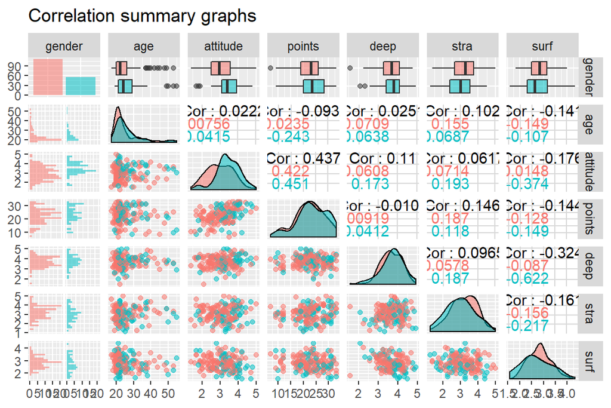

```r
library(ggplot2)
library(GGally)
p <- ggpairs(data, title = "Correlation summary graphs", mapping = aes(col = gender, alpha = 0.4), lower = list(combo = wrap('facethist', bins = 20)))

p
```

*Data contains more females than males but other variables are not dependent on gender. Participants age between 17-55. Gender independent **highest (positive) correlation is between points and attitude** (0.437) and **lowest (negative) correlation between points and deep learning approaches** (-0.0101). This could suggest that exams do not measure level of deep learning. However, points correlate best with strategic approaches (positive correlation), suggesting that focus on planning and scheduling could improve exam points.*

## Multiple linear regression fitting

To try to explain target variable **points**, I selected 3 variables that had highest negative or positive correlation (**attitude**, **stra**, **surf**) with it and fitted linear regression.

```r
linear_3_variables <- lm(points ~ attitude + stra + surf, data = data)
summary(linear_3_variables)
```

```
##
## Call:
## lm(formula = points ~ attitude + stra + surf, data = data)
##
## Residuals:
##      Min       1Q   Median       3Q      Max
## -17.1550  -3.4346   0.5156   3.6401  10.8952
##
## Coefficients:
##             Estimate Std. Error t value Pr(>|t|)
## (Intercept)  11.0171     3.6837   2.991  0.00322 **
## attitude      3.3952     0.5741   5.913 1.93e-08 ***
## stra          0.8531     0.5416   1.575  0.11716
## surf         -0.5861     0.8014  -0.731  0.46563
## ---
## Signif. codes:  0 '***' 0.001 '**' 0.01 '*' 0.05 '.' 0.1 ' ' 1
##
## Residual standard error: 5.296 on 162 degrees of freedom
## Multiple R-squared:  0.2074, Adjusted R-squared:  0.1927
## F-statistic: 14.13 on 3 and 162 DF,  p-value: 3.156e-08
```

*Attitude is the only significant variable to explain points.*

## Single linear regression (attitude)

```r
linear_attitude <- lm(points ~ attitude, data = data)
summary(linear_attitude)
```

```
##
## Call:
## lm(formula = points ~ attitude, data = data)
##
## Residuals:
##      Min       1Q   Median       3Q      Max
## -16.9763  -3.2119   0.4339   4.1534  10.6645
##
## Coefficients:
##             Estimate Std. Error t value Pr(>|t|)
## (Intercept)  11.6372     1.8303   6.358 1.95e-09 ***
## attitude      3.5255     0.5674   6.214 4.12e-09 ***
## ---
## Signif. codes:  0 '***' 0.001 '**' 0.01 '*' 0.05 '.' 0.1 ' ' 1
##
## Residual standard error: 5.32 on 164 degrees of freedom
## Multiple R-squared:  0.1906, Adjusted R-squared:  0.1856
## F-statistic: 38.61 on 1 and 164 DF,  p-value: 4.119e-09
```

*By removing non-significant variables, Adj. R<sup>2</sup> is marginally reducing, meaning that slightly less of the variance in **points** is explained by **attitude**. However, F-statistic p-value is also decreasing in a model with attitude variable alone, suggesting that the fit of a single regression model would be better for the data. Both of the models give relatively high residual std errors when compared to 1st and 3rd residual quantiles*

## Diagnostic plots for single regression

`Residuals vs Fitted values`, `Normal QQ-plot and` and `Residuals vs Leverage` diagnostic plots produced.

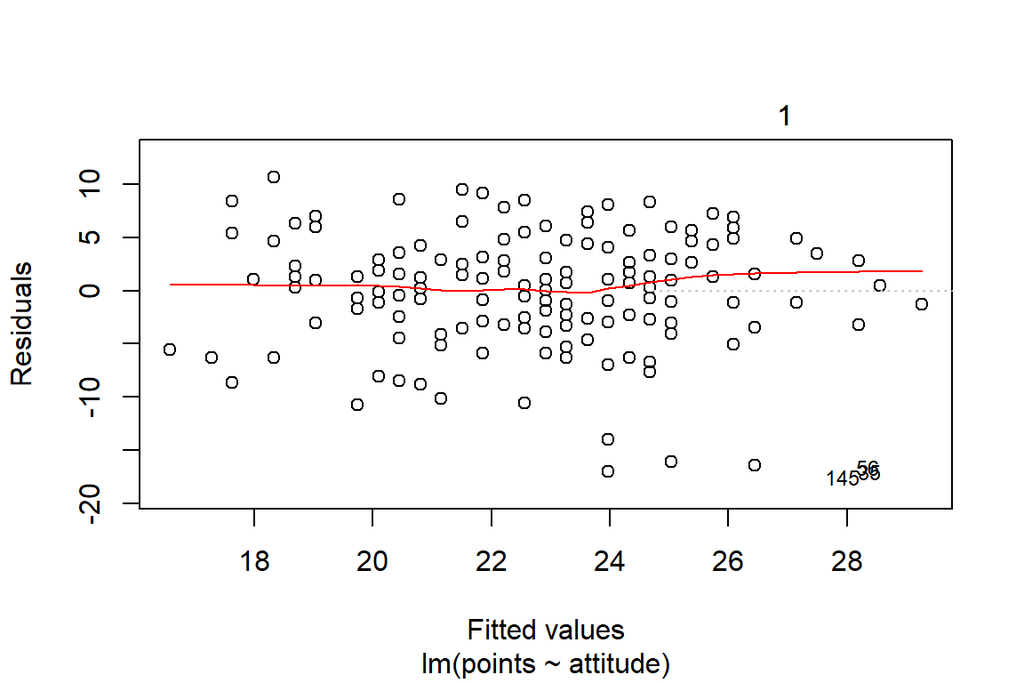

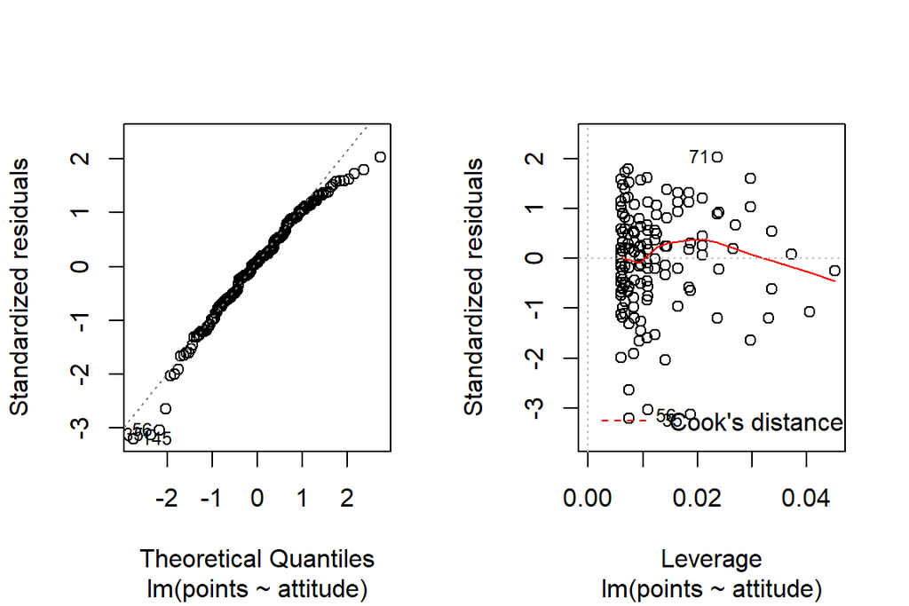

```r
plot_diagnostics2 <- plot(linear_attitude, which = c(1, 2, 5), par(mfrow = c(1,2)))
```

**Residuals vs. Fitted values**: Reasonable constant variation of residual errors, graph should not show any patterns.  
**QQ-plot:** Normality of errors is reasonable  
**Leverage:** Indicates the impact of individual points on the fitted model. My model has reasonable leverage.

## Testing stepwise multiple regression

I realized it would be slow to observe manually all possible variable combinations, so I looked for an automated one to ensure I find the best model. Here I test `ols_step_both_p` function from `olsrr package`. It is selecting variables to the model based on their p values and the thresholds to include or exclude a variable can be manually adjusted (more information here https://www.guru99.com/r-simple-multiple-linear-regression.html.

```r
library(olsrr)
fit <- lm(points ~ factor(gender) + age + attitude + deep + stra + surf, data = data)
best <- ols_step_both_p(fit)
```

```
## Stepwise Selection Method
## ---------------------------
##
## Candidate Terms:
##
## 1. factor(gender)
## 2. age
## 3. attitude
## 4. deep
## 5. stra
## 6. surf
##
## We are selecting variables based on p value...
##
## Variables Entered/Removed:
##
## - attitude added
## - stra added
## - age added
##
## No more variables to be added/removed.
##
##
## Final Model Output
## ------------------
##
##                         Model Summary
## --------------------------------------------------------------
## R                       0.467       RMSE                5.260
## R-Squared               0.218       Coef. Var          23.156
## Adj. R-Squared          0.204       MSE                27.671
## Pred R-Squared          0.176       MAE                 4.120
## --------------------------------------------------------------
##  RMSE: Root Mean Square Error
##  MSE: Mean Square Error
##  MAE: Mean Absolute Error
##
##                                 ANOVA
## ---------------------------------------------------------------------
##                 Sum of
##                Squares         DF    Mean Square      F         Sig.
## ---------------------------------------------------------------------
## Regression    1250.931          3        416.977    15.069    0.0000
## Residual      4482.762        162         27.671
## Total         5733.693        165
## ---------------------------------------------------------------------
##
##                                   Parameter Estimates
## ----------------------------------------------------------------------------------------
##       model      Beta    Std. Error    Std. Beta      t        Sig      lower     upper
## ----------------------------------------------------------------------------------------
## (Intercept)    10.895         2.648                  4.114    0.000     5.666    16.125
##    attitude     3.481         0.562        0.431     6.191    0.000     2.371     4.591
##        stra     1.004         0.534        0.131     1.878    0.062    -0.051     2.059
##         age    -0.088         0.053       -0.116    -1.664    0.098    -0.193     0.016
## ----------------------------------------------------------------------------------------
```

```r
best
```

```
##
##                              Stepwise Selection Summary
## -------------------------------------------------------------------------------------
##                      Added/                   Adj.
## Step    Variable    Removed     R-Square    R-Square     C(p)        AIC        RMSE
## -------------------------------------------------------------------------------------
##    1    attitude    addition       0.191       0.186    5.3960    1029.9875    5.3197
##    2      stra      addition       0.205       0.195    4.4470    1029.0379    5.2888
##    3      age       addition       0.218       0.204    3.6840    1028.2247    5.2604
## -------------------------------------------------------------------------------------
```

## Best fit diagnostic plots

```r
best_fit <- lm(points ~ attitude + stra + age, data = data)
summary(best_fit)
```

```
##
## Call:
## lm(formula = points ~ attitude + stra + age, data = data)
##
## Residuals:
##      Min       1Q   Median       3Q      Max
## -18.1149  -3.2003   0.3303   3.4129  10.7599
##
## Coefficients:
##             Estimate Std. Error t value Pr(>|t|)
## (Intercept) 10.89543    2.64834   4.114 6.17e-05 ***
## attitude     3.48077    0.56220   6.191 4.72e-09 ***
## stra         1.00371    0.53434   1.878   0.0621 .
## age         -0.08822    0.05302  -1.664   0.0981 .
## ---
## Signif. codes:  0 '***' 0.001 '**' 0.01 '*' 0.05 '.' 0.1 ' ' 1
##
## Residual standard error: 5.26 on 162 degrees of freedom
## Multiple R-squared:  0.2182, Adjusted R-squared:  0.2037
## F-statistic: 15.07 on 3 and 162 DF,  p-value: 1.07e-08
```

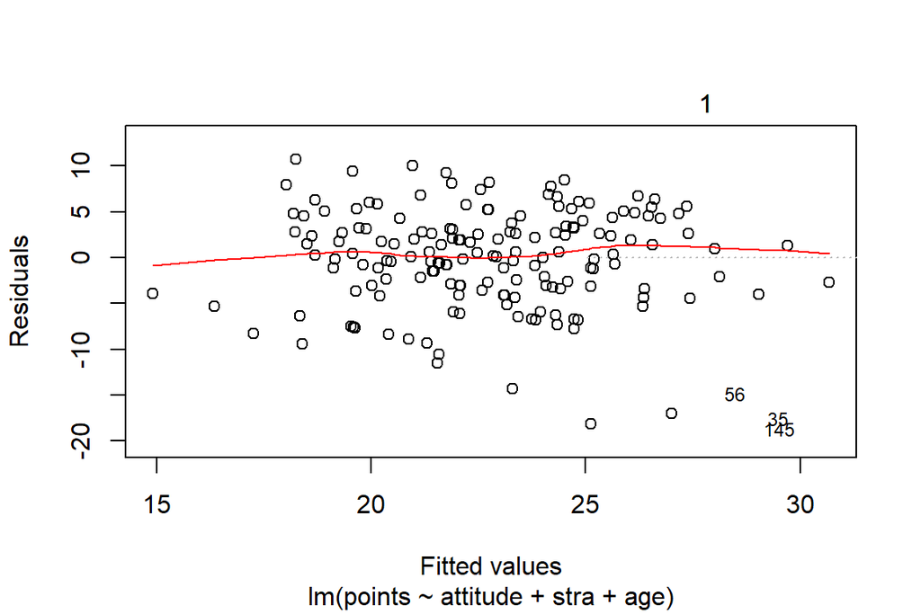

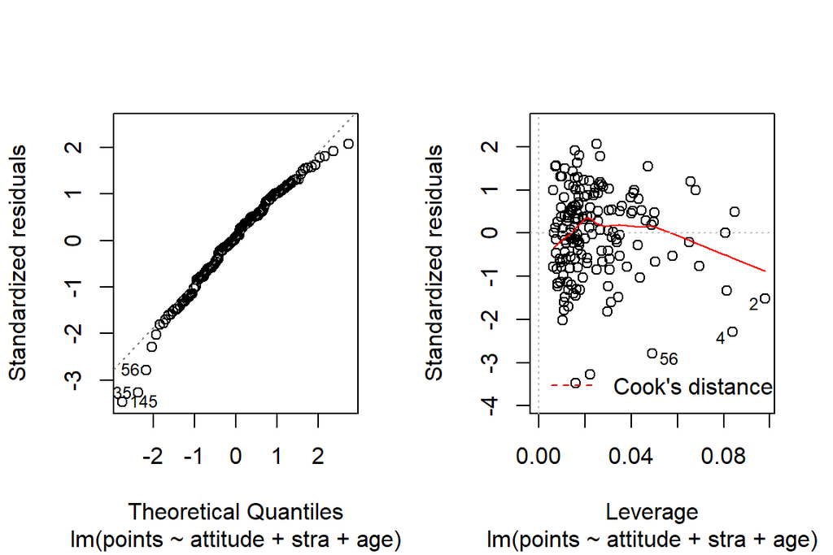

```r
best_fit_diagn <- plot(best_fit, which = c(1, 2, 5), par(mfrow = c(1,2)))
```

## Comparison of different models

```r
anova <- anova(linear_3_variables, linear_attitude, best_fit)
anova
```

```
## Analysis of Variance Table
##
## Model 1: points ~ attitude + stra + surf
## Model 2: points ~ attitude
## Model 3: points ~ attitude + stra + age
##   Res.Df    RSS Df Sum of Sq      F  Pr(>F)
## 1    162 4544.4
## 2    164 4641.1 -2   -96.743 1.7244 0.18154
## 3    162 4482.8  2   158.355 2.8226 0.06238 .
## ---
## Signif. codes:  0 '***' 0.001 '**' 0.01 '*' 0.05 '.' 0.1 ' ' 1
```

Parameters from all three models in one table:

```r
library(stargazer)
table <- stargazer(linear_3_variables, linear_attitude, best_fit, title='Results', type="html", align = TRUE)
```

**Results**

|  | *Dependent variable:* |  |  |
| --- | --- | --- | --- |
|  | points |  |  |
|  | (1) | (2) | (3) |
| attitude | 3.395*** | 3.525*** | 3.481*** |
|  | (0.574) | (0.567) | (0.562) |
| stra | 0.853 |  | 1.004* |
|  | (0.542) |  | (0.534) |
| surf | -0.586 |  |  |
|  | (0.801) |  |  |
| age |  |  | -0.088* |
|  |  |  | (0.053) |
| Constant | 11.017*** | 11.637*** | 10.895*** |
|  | (3.684) | (1.830) | (2.648) |
| Observations | 166 | 166 | 166 |
| R<sup>2</sup> | 0.207 | 0.191 | 0.218 |
| Adjusted R<sup>2</sup> | 0.193 | 0.186 | 0.204 |
| Residual Std. Error | 5.296 (df = 162) | 5.320 (df = 164) | 5.260 (df = 162) |
| F Statistic | 14.132*** (df = 3; 162) | 38.608*** (df = 1; 164) | 15.069*** (df = 3; 162) |
| *Note:* | p<0.1; p<0.05; p<0.01 |  |  |

## Multicollinearity detection

`corrplot` to visualize correlations between different variables easily.

```r
library(corrplot)
#Select only numeric columns
drops <- c("gender")
numeric_df <- data[ , !(names(data) %in% drops)]
head(numeric_df)
```

```
##   age attitude points     deep  stra     surf
## 1  53      3.7     25 3.583333 3.375 2.583333
## 2  55      3.1     12 2.916667 2.750 3.166667
## 3  49      2.5     24 3.500000 3.625 2.250000
## 4  53      3.5     10 3.500000 3.125 2.250000
## 5  49      3.7     22 3.666667 3.625 2.833333
## 6  38      3.8     21 4.750000 3.625 2.416667
```

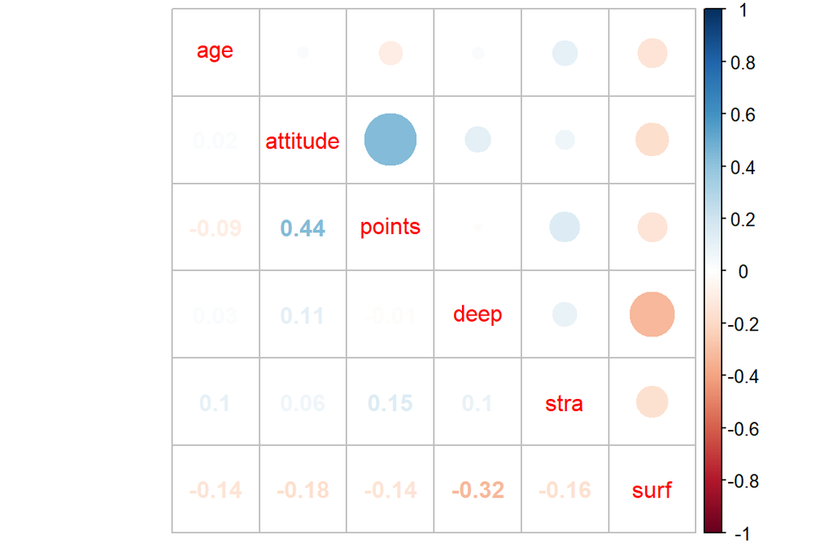

```r
cor1 = cor(numeric_df)
corrplot.mixed(cor1)
```

`mctest` and `ppcor` packages to test multicollinearity. Multicollinearity was detected between surf and deep. However, deep was not included in any of the regression models so this multicollinearity is not affecting the models.

```r
library(mctest)
library(ppcor)
omcdiag(numeric_df[,c(1:2,4:6)],numeric_df$points)
```

```
##
## Call:
## omcdiag(x = numeric_df[, c(1:2, 4:6)], y = numeric_df$points)
##
##
## Overall Multicollinearity Diagnostics
##
##                        MC Results detection
## Determinant |X'X|:         0.8167         0
## Farrar Chi-Square:        32.8984         1
## Red Indicator:             0.1478         0
## Sum of Lambda Inverse:     5.4072         0
## Theil's Method:           -0.5624         0
## Condition Number:         35.1278         1
##
## 1 --> COLLINEARITY is detected by the test
## 0 --> COLLINEARITY is not detected by the test
```

```r
imcdiag(numeric_df[,c(1:2,4:6)],numeric_df$points)
```

```
##
## Call:
## imcdiag(x = numeric_df[, c(1:2, 4:6)], y = numeric_df$points)
##
##
## All Individual Multicollinearity Diagnostics Result
##
##             VIF    TOL     Wi     Fi Leamer   CVIF Klein   IND1   IND2
## age      1.0280 0.9728 1.1251 1.5095 0.9863 1.0420     0 0.0242 0.3754
## attitude 1.0363 0.9650 1.4596 1.9583 0.9823 1.0505     0 0.0240 0.4832
## deep     1.1239 0.8898 4.9871 6.6908 0.9433 1.1393     0 0.0221 1.5220
## stra     1.0371 0.9642 1.4925 2.0023 0.9820 1.0513     0 0.0240 0.4936
## surf     1.1820 0.8460 7.3251 9.8275 0.9198 1.1982     0 0.0210 2.1257
##
## 1 --> COLLINEARITY is detected by the test
## 0 --> COLLINEARITY is not detected by the test
##
## age , deep , stra , surf , coefficient(s) are non-significant may be due to multicollinearity
##
## R-square of y on all x: 0.2311
##
## * use method argument to check which regressors may be the reason of collinearity
## ===================================
```

```r
pcor(numeric_df[,c(1:2,4:6)], method=c("pearson"))
```

```
## $estimate
##                   age     attitude        deep        stra       surf
## age       1.000000000 -0.004073822 -0.02583547  0.08280593 -0.1282109
## attitude -0.004073822  1.000000000  0.05566725  0.03205301 -0.1424926
## deep     -0.025835471  0.055667246  1.00000000  0.04761982 -0.3028222
## stra      0.082805932  0.032053011  0.04761982  1.00000000 -0.1195590
## surf     -0.128210938 -0.142492609 -0.30282221 -0.11955903  1.0000000
##
## $p.value
##                age   attitude         deep      stra         surf
## age      0.0000000 0.95883864 7.433945e-01 0.2933205 1.028842e-01
## attitude 0.9588386 0.00000000 4.803189e-01 0.6846100 6.960177e-02
## deep     0.7433945 0.48031888 0.000000e+00 0.5460878 8.527154e-05
## stra     0.2933205 0.68460999 5.460878e-01 0.0000000 1.284762e-01
## surf     0.1028842 0.06960177 8.527154e-05 0.1284762 0.000000e+00
##
## $statistic
##                  age    attitude       deep       stra      surf
## age       0.00000000 -0.05169143 -0.3279248  1.0543103 -1.640352
## attitude -0.05169143  0.00000000  0.7074351  0.4069162 -1.826668
## deep     -0.32792484  0.70743513  0.0000000  0.6049140 -4.031682
## stra      1.05431032  0.40691620  0.6049140  0.0000000 -1.527994
## surf     -1.64035239 -1.82666808 -4.0316824 -1.5279942  0.000000
##
## $n
## [1] 166
##
## $gp
## [1] 3
##
## $method
## [1] "pearson"
```

## Conclusions

Overall power of the fitted models to explain points variablity is limited. Adjusted R<sup>2</sup> is quite low for all explored models and residual errors remain quite high. Based on F-statistics p-value, and observation that attitude was the only significant variable associated with points, single regression model could be sufficient model to use for rougly estimate student’s future achievements in exams. The better the attitude of a student is, the higher exam points they are likely to have which makes sense.  
However, `olsrr` library function pinpointed a multiple regression model (**attitude**, **stra** and **age**) that explains points variation even better. Rough interpretation of this model:  
1. Higher attitude -> Higher points (positive correlation)  
2. Higher strategic approach -> Higher points (positive correlation)  
3. Older age -> Lower points (negative correlation)  
4. Impact of these three variables on points is: attitude > stra > age

# Chapter 3: Logistic regression analysis to predict alcohol consumption

In this exercise I analyze preprocessed data.

### Link to preprocessing R script:

https://github.com/neabister/IODS-project/blob/master/data/create_alc.R

### Link to original data:

https://archive.ics.uci.edu/ml/datasets/Student+Performance

### Original data and preprocessing

Original data sets consist of students from Math (1) and Portuguese language (2) classes who answered to several questions to assess their economical, family and activity status, and variables related to studying and alcoholc consumption. In data pre-processing, individual students were identified based on combination of 13 variables and only students present in both datasets were selected.

Alcohol use was evaluated numerically, separately for weekdays and weekends. To quantify overall consumption, average for these 2 variables was calculated into column `alc_use`. To group students into high and low alcohol use, threshold of 2 was applied to identify students with high alcohol use in a column `high_use`.

## Read and explore the data

```r
data <- read.csv('data/create_alc.csv', sep=',')
head(data)
```

```
##   school sex age address famsize Pstatus Medu Fedu     Mjob     Fjob
## 1     GP   F  18       U     GT3       A    4    4  at_home  teacher
## 2     GP   F  17       U     GT3       T    1    1  at_home    other
## 3     GP   F  15       U     LE3       T    1    1  at_home    other
## 4     GP   F  15       U     GT3       T    4    2   health services
## 5     GP   F  16       U     GT3       T    3    3    other    other
## 6     GP   M  16       U     LE3       T    4    3 services    other
##       reason nursery internet guardian traveltime studytime failures
## 1     course     yes       no   mother          2         2        0
## 2     course      no      yes   father          1         2        0
## 3      other     yes      yes   mother          1         2        2
## 4       home     yes      yes   mother          1         3        0
## 5       home     yes       no   father          1         2        0
## 6 reputation     yes      yes   mother          1         2        0
##   schoolsup famsup paid activities higher romantic famrel freetime goout
## 1       yes     no   no         no    yes       no      4        3     4
## 2        no    yes   no         no    yes       no      5        3     3
## 3       yes     no  yes         no    yes       no      4        3     2
## 4        no    yes  yes        yes    yes      yes      3        2     2
## 5        no    yes  yes         no    yes       no      4        3     2
## 6        no    yes  yes        yes    yes       no      5        4     2
##   Dalc Walc health absences G1 G2 G3 alc_use high_use
## 1    1    1      3        5  2  8  8     1.0    FALSE
## 2    1    1      3        3  7  8  8     1.0    FALSE
## 3    2    3      3        8 10 10 11     2.5     TRUE
## 4    1    1      5        1 14 14 14     1.0    FALSE
## 5    1    2      5        2  8 12 12     1.5    FALSE
## 6    1    2      5        8 14 14 14     1.5    FALSE
```

```r
dim(data)
```

```
## [1] 382  35
```

```r
str(data)
```

```
## 'data.frame':    382 obs. of  35 variables:
##  $ school    : Factor w/ 2 levels "GP","MS": 1 1 1 1 1 1 1 1 1 1 ...
##  $ sex       : Factor w/ 2 levels "F","M": 1 1 1 1 1 2 2 1 2 2 ...
##  $ age       : int  18 17 15 15 16 16 16 17 15 15 ...
##  $ address   : Factor w/ 2 levels "R","U": 2 2 2 2 2 2 2 2 2 2 ...
##  $ famsize   : Factor w/ 2 levels "GT3","LE3": 1 1 2 1 1 2 2 1 2 1 ...
##  $ Pstatus   : Factor w/ 2 levels "A","T": 1 2 2 2 2 2 2 1 1 2 ...
##  $ Medu      : int  4 1 1 4 3 4 2 4 3 3 ...
##  $ Fedu      : int  4 1 1 2 3 3 2 4 2 4 ...
##  $ Mjob      : Factor w/ 5 levels "at_home","health",..: 1 1 1 2 3 4 3 3 4 3 ...
##  $ Fjob      : Factor w/ 5 levels "at_home","health",..: 5 3 3 4 3 3 3 5 3 3 ...
##  $ reason    : Factor w/ 4 levels "course","home",..: 1 1 3 2 2 4 2 2 2 2 ...
##  $ nursery   : Factor w/ 2 levels "no","yes": 2 1 2 2 2 2 2 2 2 2 ...
##  $ internet  : Factor w/ 2 levels "no","yes": 1 2 2 2 1 2 2 1 2 2 ...
##  $ guardian  : Factor w/ 3 levels "father","mother",..: 2 1 2 2 1 2 2 2 2 2 ...
```

[output cut: 21 more lines]

Dataset has 35 variables and 382 observations (students). Data describes several background informations collected from students attending both math and portuguese language.

## Personal hypothesis prior to analysis

Four interesting variables that could predict high alcohol consumption:

1. absences
   - High alcohol use could lead to more absences
2. Pstatus (together, apart)
   - Perhaps problematic alcohol use could be more likely in broken families
3. sex
   - Male gender could predispose to high alcohol use
4. goout
   - Could lead to higher alcohol use (being problematic use or not) because students going out often involves alcohol

```r
interesting_variables <- c('absences', 'Pstatus', 'sex', 'goout', 'high_use')
```

## Graphical data exploration & Summary statistics

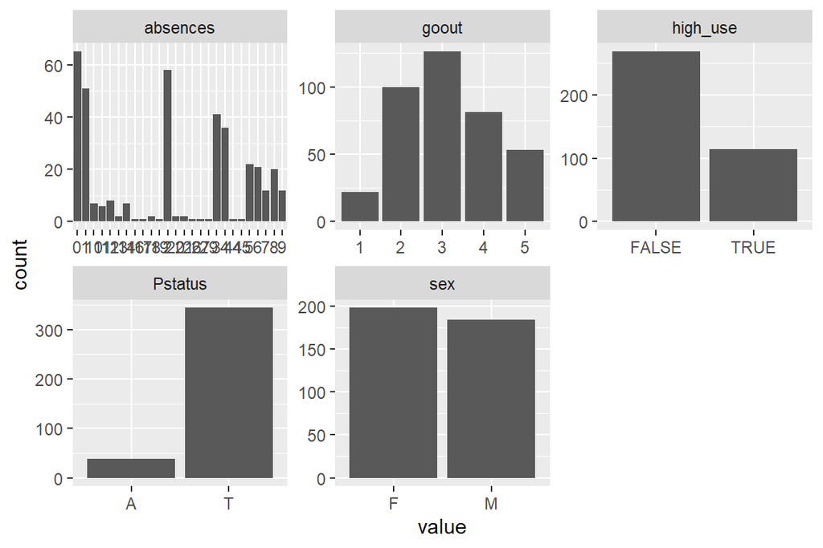

```r
library(dplyr)
library(tidyr)
library(ggplot2)
library(gridExtra)

interesting <- select(data, one_of(interesting_variables))
gather(interesting) %>% ggplot(aes(value)) + facet_wrap("key", scales = "free") + geom_bar()
```

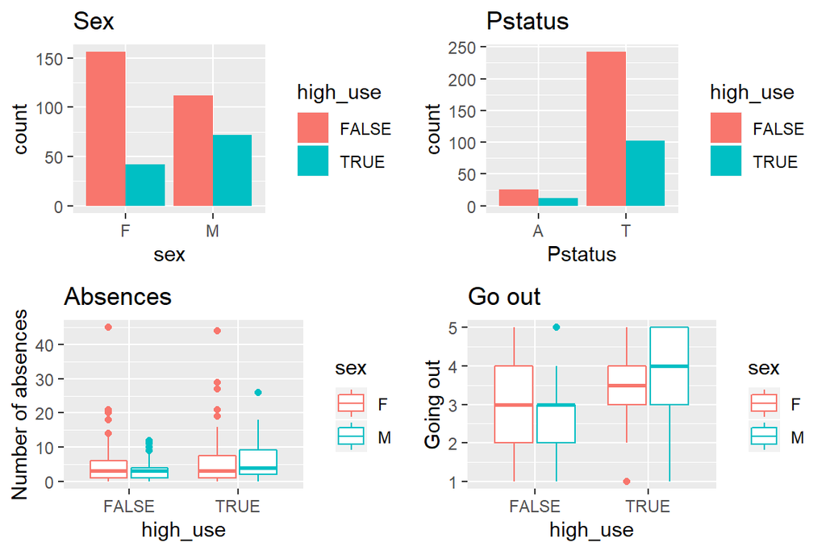

```r
sex_plot <- ggplot(interesting, aes(sex, fill = high_use))
p1 <- sex_plot + geom_bar(position = 'dodge') + ggtitle('Sex')

Pstatus_plot <- ggplot(interesting, aes(Pstatus, fill = high_use))
p2 <- Pstatus_plot + geom_bar(position = 'dodge') + ggtitle('Pstatus')

absences_plot <- ggplot(interesting, aes(x = high_use, y = absences, col = sex))
p3 <- absences_plot + geom_boxplot() + ylab("Number of absences") + ggtitle('Absences')

goout_plot <- ggplot(interesting, aes(x = high_use, y = goout, col = sex))
p4 <- goout_plot + geom_boxplot() + ylab("Going out") + ggtitle('Go out')

grid.arrange(p1, p2, p3, p4, nrow=2)
```

Findings:  
1. *Sex*: Larger fraction of male students have high alcohol consumption than female. Initial hypothesis would hold true.  
2. *Parents together/separated*: Most of the parents are together. Hard to say from the plot if fraction of student with high alcohol consumption would be found in separated families (effect is not as dramatic as with sex).  
3. *Absences*: Data is quite spread especially among female students. Trend of more absences in high alcohol use is clearer in males.  
4. *Go out*: Again positive correlation between going out and high alcohol use, which again clearer in male students.

My hypotheses are not completely useless at least.

## Summary statistics by group

Below is table showing mean values for `absences` and `goout` between low and high alcohol use, separately for male and female students. It seems that both measured variables have higher mean value in high alcohol use group than in low use, this is true for both sexes. However, difference may not be statistically significant (based on how plots look above). Anyway, these variables may have some predictive power for logistic model.

```r
interesting %>% group_by(sex, high_use) %>% summarise(count = n(), mean_absences = mean(absences), mean_goout = mean(goout))
```

```
## # A tibble: 4 x 5
## # Groups:   sex [2]
##   sex   high_use count mean_absences mean_goout
##   <fct> <lgl>    <int>         <dbl>      <dbl>
## 1 F     FALSE      156          4.22       2.96
## 2 F     TRUE        42          6.79       3.36
## 3 M     FALSE      112          2.98       2.71
## 4 M     TRUE        72          6.12       3.93
```

## Logistic regression fitting

```r
model1 <- glm(high_use ~ sex + Pstatus + absences + goout, data = interesting, family = 'binomial')

summary(model1)
```

```
##
## Call:
## glm(formula = high_use ~ sex + Pstatus + absences + goout, family = "binomial",
##     data = interesting)
##
## Deviance Residuals:
##     Min       1Q   Median       3Q      Max
## -1.7870  -0.8152  -0.5445   0.8351   2.4742
##
## Coefficients:
##              Estimate Std. Error z value Pr(>|z|)
## (Intercept) -4.160820   0.600994  -6.923 4.41e-12 ***
## sexM         0.958756   0.254654   3.765 0.000167 ***
## PstatusT    -0.002673   0.418684  -0.006 0.994905
## absences     0.084166   0.022546   3.733 0.000189 ***
## goout        0.729844   0.119827   6.091 1.12e-09 ***
## ---
## Signif. codes:  0 '***' 0.001 '**' 0.01 '*' 0.05 '.' 0.1 ' ' 1
##
## (Dispersion parameter for binomial family taken to be 1)
##
##     Null deviance: 465.68  on 381  degrees of freedom
## Residual deviance: 387.75  on 377  degrees of freedom
## AIC: 397.75
##
## Number of Fisher Scoring iterations: 4
```

```r
coef(model1)
```

```
##  (Intercept)         sexM     PstatusT     absences        goout
## -4.160819757  0.958756213 -0.002673494  0.084165775  0.729844092
```

1. Sex, male: positive effect on high_use
2. Pstatus, together: non-significant effect on high_use
3. Absences: positive effect on high_use
4. Go out: positive effect on high_use

Deviance = measure of goodness of fit, higher number indicates worse fit  
- Null deviance = When only intercept is included to the model  
- Residual deviance = Includes all variables in the model -> Residual deviance is a bit lower than null

AIC = compare different models, lower is better

## Odds ratio and confidence intervals

```r
OR <- coef(model1) %>% exp
CI <- confint(model1) %>% exp
cbind(OR, CI)
```

```
##                     OR       2.5 %     97.5 %
## (Intercept) 0.01559477 0.004551627 0.04836831
## sexM        2.60845010 1.592994654 4.33230471
## PstatusT    0.99733008 0.448239957 2.34168647
## absences    1.08780921 1.042121298 1.13966390
## goout       2.07475711 1.649860733 2.64195732
```

Odds ratio >1 implies increased likelyhood that student’s consumption of alcohol is high. If 1 is included in the CI, it means that interval spans from below 1 to more than 1 and the variable has no predictive power on dependent variable. Thus, from CI and OR table can be concluded that male sex and going out increase the likelyhood that person’s alcohol consumption is high. Absences seem to have small effect whereas Pstatus does not have effect on alcohol consumtpion (also seen from model summary where this variable is the only one that is not significant).

## Analysis of predictive power

Since Pstatus was not significant variable, I will fit a new model (`model2`) without it and evaluate how well it predicts high_use in this same data set. First I am calculating probabilities of high_use with the `model2` and appending this information in dataframe `interesting` that contains all my interesting variables. Additionally, I am generating a column for prediction of high_use that gets value `TRUE` if probability is >0.5 and `FALSE` if <0.5.

```r
model2 <- glm(high_use ~ sex + absences + goout, data = interesting, family = 'binomial')

probabilities <- predict(model2, type = 'response')

interesting <- mutate(interesting, probability = probabilities)

interesting <- mutate(interesting, predicted_high_use = probability > 0.5)

head(interesting)
```

```
##   absences Pstatus sex goout high_use probability predicted_high_use
## 1        5       A   F     4    FALSE  0.30512370              FALSE
## 2        3       T   F     3    FALSE  0.15171754              FALSE
## 3        8       T   F     2     TRUE  0.11608053              FALSE
## 4        1       T   F     2    FALSE  0.06790218              FALSE
## 5        2       T   F     2    FALSE  0.07342805              FALSE
## 6        8       T   M     2    FALSE  0.25514399              FALSE
```

To assess model’s prediction power, I am checking how often prediction and real values are matching

```r
table(high_use = interesting$high_use, prediction = interesting$predicted_high_use)
```

```
##         prediction
## high_use FALSE TRUE
##    FALSE   253   15
##    TRUE     65   49
```

### Visualizing

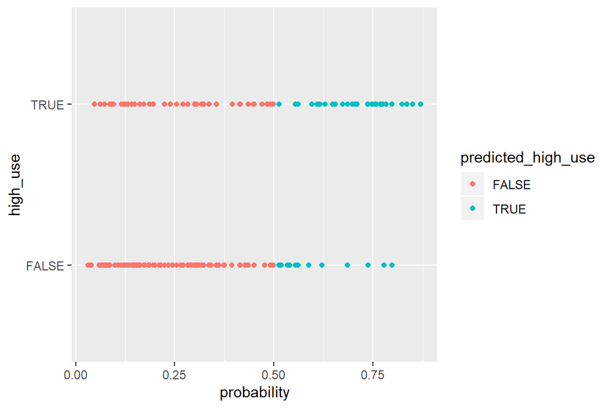

```r
g <- ggplot(interesting, aes(x = probability, y = high_use, col = predicted_high_use))
g + geom_point()
```

```r
# tabulate the target variable versus the predictions
table(high_use = interesting$high_use, prediction = interesting$predicted_high_use) %>% prop.table %>% addmargins
```

```
##         prediction
## high_use      FALSE       TRUE        Sum
##    FALSE 0.66230366 0.03926702 0.70157068
##    TRUE  0.17015707 0.12827225 0.29842932
##    Sum   0.83246073 0.16753927 1.00000000
```

```r
sensitivity <- 0.1283 / 0.2984 * 100
specificity <- 0.6623 / 0.7016 * 100
```

Model sensitivity is 42.9959786 % and specificity 94.3985177 %, meaning that it is not predicting false positives too easily but is more vulnerable to miss true positives (predicts more false negatives).

## Step-wise best model selection

Since 4 interesting variables were chosen quite randomly in the first place, I want to explore options to find the best model more automatically. Here I will use `step()` function to test models with different variables included.

```r
#select all except Dalc and Walc
variables_for_step <- dplyr::select(data, -Dalc, -Walc)
#select independent variables (all except alc_use which are two last columns)
names_variables <- colnames(variables_for_step)
variables_used <- names_variables[seq_len(length(names_variables)-2)]

#Constructing formula to use for step-wise model search
Formula <- formula(paste("high_use ~ ", paste(variables_used, collapse=" + ")))
```

Running `step()` function with build `Formula`. It takes some time and output is very long so output is hidden.

```r
model3 <- glm(Formula, data = variables_for_step, family = 'binomial')
step(model3, direction = "backward")
```

Below is the function with lowest AIC found by `step()`

```r
#Final best fit variables
model_best <- glm(high_use ~ sex + address + Fjob + traveltime + studytime + paid + activities + famrel + freetime + goout + absences, family = "binomial",
    data = variables_for_step)
```

## Compare 3 logistic models

```r
anova <- anova(model_best, model1, model2)
anova
```

```
## Analysis of Deviance Table
##
## Model 1: high_use ~ sex + address + Fjob + traveltime + studytime + paid +
##     activities + famrel + freetime + goout + absences
## Model 2: high_use ~ sex + Pstatus + absences + goout
## Model 3: high_use ~ sex + absences + goout
##   Resid. Df Resid. Dev  Df Deviance
## 1       367     348.24
## 2       377     387.75 -10  -39.519
## 3       378     387.75  -1    0.000
```

```r
library(stargazer)
table <- stargazer(model_best, model1, model2, title='Comparison of logistic regression models', type="html", align = TRUE)
```

**Comparison of logistic regression models**

|  | *Dependent variable:* |  |  |
| --- | --- | --- | --- |
|  | high_use |  |  |
|  | (1) | (2) | (3) |
| sexM | 0.938*** | 0.959*** | 0.959*** |
|  | (0.292) | (0.255) | (0.255) |
| addressU | -0.634* |  |  |
|  | (0.341) |  |  |
| Fjobhealth | 0.827 |  |  |
|  | (1.057) |  |  |
| Fjobother | 0.694 |  |  |
|  | (0.834) |  |  |
| Fjobservices | 1.408* |  |  |
|  | (0.854) |  |  |
| Fjobteacher | -0.0004 |  |  |
|  | (0.971) |  |  |
| traveltime | 0.298 |  |  |
|  | (0.203) |  |  |
| studytime | -0.392** |  |  |
|  | (0.183) |  |  |
| paidyes | 0.610** |  |  |
|  | (0.278) |  |  |
| activitiesyes | -0.527* |  |  |
|  | (0.278) |  |  |
| famrel | -0.458*** |  |  |
|  | (0.152) |  |  |
| freetime | 0.214 |  |  |
|  | (0.151) |  |  |
| PstatusT |  | -0.003 |  |
|  |  | (0.419) |  |
| goout | 0.766*** | 0.730*** | 0.730*** |
|  | (0.135) | (0.120) | (0.120) |
| absences | 0.082*** | 0.084*** | 0.084*** |
|  | (0.023) | (0.023) | (0.022) |
| Constant | -3.200*** | -4.161*** | -4.163*** |
|  | (1.216) | (0.601) | (0.475) |
| Observations | 382 | 382 | 382 |
| Log Likelihood | -174.118 | -193.877 | -193.877 |
| Akaike Inf. Crit. | 378.236 | 397.755 | 395.755 |
| *Note:* | p<0.1; p<0.05; p<0.01 |  |  |

```r
probabilities1 <- predict(model1, type = 'response')
probabilities2 <- predict(model2, type = 'response')
probabilities_model_best <- predict(model_best, type = 'response')

predictions_3_models <- mutate(variables_for_step, probability_model1 = probabilities1, probability_model2 = probabilities2, probability_best = probabilities_model_best)

predictions_3_models <- mutate(predictions_3_models, predicted_high_use_m1 = probability_model1 > 0.5, predicted_high_use_m2 = probability_model2 > 0.5,
                               predicted_high_use_best = probability_best > 0.5)
```

### 2x2 tables for models

```r
model1_table <- table(high_use = predictions_3_models$high_use, prediction_model1 = predictions_3_models$predicted_high_use_m1) %>% prop.table %>% addmargins
model2_table <- table(high_use = predictions_3_models$high_use, prediction_model2 = predictions_3_models$predicted_high_use_m2) %>% prop.table %>% addmargins
best_model_table <- table(high_use = predictions_3_models$high_use, prediction_best_model = predictions_3_models$predicted_high_use_best) %>% prop.table %>% addmargins

model1_table
```

```
##         prediction_model1
## high_use      FALSE       TRUE        Sum
##    FALSE 0.66230366 0.03926702 0.70157068
##    TRUE  0.17015707 0.12827225 0.29842932
##    Sum   0.83246073 0.16753927 1.00000000
```

```r
model2_table
```

```
##         prediction_model2
## high_use      FALSE       TRUE        Sum
##    FALSE 0.66230366 0.03926702 0.70157068
##    TRUE  0.17015707 0.12827225 0.29842932
##    Sum   0.83246073 0.16753927 1.00000000
```

```r
best_model_table
```

```
##         prediction_best_model
## high_use      FALSE       TRUE        Sum
##    FALSE 0.65445026 0.04712042 0.70157068
##    TRUE  0.14659686 0.15183246 0.29842932
##    Sum   0.80104712 0.19895288 1.00000000
```

```r
# Calculate sensitivity and specificity for all models
sensitivity_m1 <- 0.1283 / 0.2984 * 100
specificity_m1 <- 0.6623 / 0.7016 * 100


sensitivity_m2 <- 0.1283 / 0.2984 * 100
specificity_m2 <- 0.6623 / 0.7016 * 100

sensitivity_best <- 0.1518 / 0.2984 * 100
specificity_best <- 0.6545 / 0.7016 * 100

#Collect accuracy parameters in one df
model_accuracy <- data.frame("Model" = c('Model 1', 'Model 2', 'Best model'), "Sensitivity" = c(sensitivity_m1, sensitivity_m2, sensitivity_best), "Specificity" = c(specificity_m1, specificity_m2, specificity_best))

print(model_accuracy, digits = 3)
```

```
##        Model Sensitivity Specificity
## 1    Model 1        43.0        94.4
## 2    Model 2        43.0        94.4
## 3 Best model        50.9        93.3
```

### Graphical visualization of models

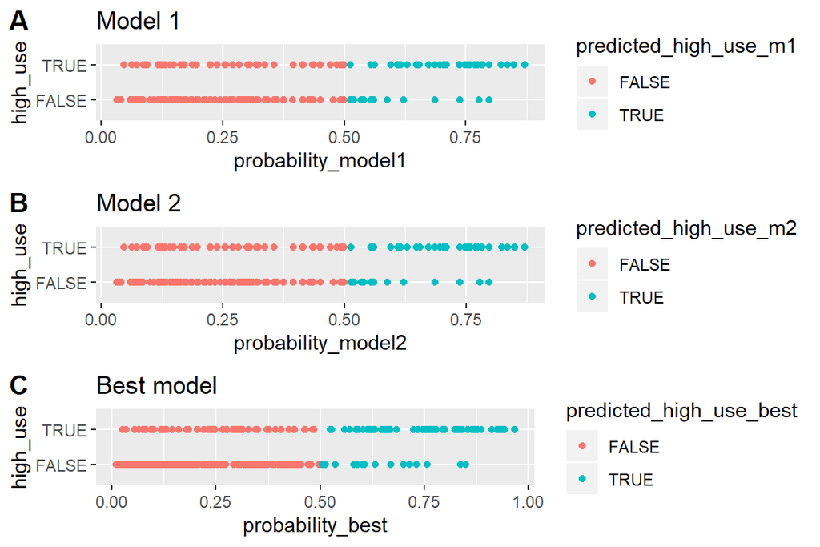

```r
#Nice examples for plot arrangements http://www.sthda.com/english/wiki/wiki.php?id_contents=7930
library(cowplot)
m1_plot <- ggplot(predictions_3_models, aes(x = probability_model1, y = high_use, col = predicted_high_use_m1))
m2_plot <- ggplot(predictions_3_models, aes(x = probability_model2, y = high_use, col = predicted_high_use_m2))
best_plot <- ggplot(predictions_3_models, aes(x = probability_best, y = high_use, col = predicted_high_use_best))

g1 <- m1_plot + geom_point() + ggtitle('Model 1')
g2 <- m2_plot + geom_point() + ggtitle('Model 2')
g3 <- best_plot + geom_point() + ggtitle('Best model')

plot_grid(g1, g2, g3, labels=c("A", "B", "C"), ncol = 1, nrow = 3)
```

## Conclusions

Selection of a model is always a trade of between specificity, sensitivity and complexity of the model. If we allow more complex model, I would select `best_model` because of significantly improved **sensitivity** compared to other models, even if there is slight drop in **specificity**.

# Chapter 4: Clustering

In this exercise I analyze `Boston`data set available in `MASS` package.

### More information on Boston data set:

https://stat.ethz.ch/R-manual/R-devel/library/MASS/html/Boston.html

## Loading MASS and Boston data set

`Boston` data set contains information from 506 housing observation (rows) with 14 different variables (columns).

```r
library(MASS)
data('Boston')

str(Boston)
```

```
## 'data.frame':    506 obs. of  14 variables:
##  $ crim   : num  0.00632 0.02731 0.02729 0.03237 0.06905 ...
##  $ zn     : num  18 0 0 0 0 0 12.5 12.5 12.5 12.5 ...
##  $ indus  : num  2.31 7.07 7.07 2.18 2.18 2.18 7.87 7.87 7.87 7.87 ...
##  $ chas   : int  0 0 0 0 0 0 0 0 0 0 ...
##  $ nox    : num  0.538 0.469 0.469 0.458 0.458 0.458 0.524 0.524 0.524 0.524 ...
##  $ rm     : num  6.58 6.42 7.18 7 7.15 ...
##  $ age    : num  65.2 78.9 61.1 45.8 54.2 58.7 66.6 96.1 100 85.9 ...
##  $ dis    : num  4.09 4.97 4.97 6.06 6.06 ...
##  $ rad    : int  1 2 2 3 3 3 5 5 5 5 ...
##  $ tax    : num  296 242 242 222 222 222 311 311 311 311 ...
##  $ ptratio: num  15.3 17.8 17.8 18.7 18.7 18.7 15.2 15.2 15.2 15.2 ...
##  $ black  : num  397 397 393 395 397 ...
##  $ lstat  : num  4.98 9.14 4.03 2.94 5.33 ...
##  $ medv   : num  24 21.6 34.7 33.4 36.2 28.7 22.9 27.1 16.5 18.9 ...
```

```r
summary(Boston)
```

```
##       crim                zn             indus            chas
##  Min.   : 0.00632   Min.   :  0.00   Min.   : 0.46   Min.   :0.00000
##  1st Qu.: 0.08204   1st Qu.:  0.00   1st Qu.: 5.19   1st Qu.:0.00000
##  Median : 0.25651   Median :  0.00   Median : 9.69   Median :0.00000
##  Mean   : 3.61352   Mean   : 11.36   Mean   :11.14   Mean   :0.06917
##  3rd Qu.: 3.67708   3rd Qu.: 12.50   3rd Qu.:18.10   3rd Qu.:0.00000
##  Max.   :88.97620   Max.   :100.00   Max.   :27.74   Max.   :1.00000
##       nox               rm             age              dis
##  Min.   :0.3850   Min.   :3.561   Min.   :  2.90   Min.   : 1.130
##  1st Qu.:0.4490   1st Qu.:5.886   1st Qu.: 45.02   1st Qu.: 2.100
##  Median :0.5380   Median :6.208   Median : 77.50   Median : 3.207
##  Mean   :0.5547   Mean   :6.285   Mean   : 68.57   Mean   : 3.795
##  3rd Qu.:0.6240   3rd Qu.:6.623   3rd Qu.: 94.08   3rd Qu.: 5.188
##  Max.   :0.8710   Max.   :8.780   Max.   :100.00   Max.   :12.127
##       rad              tax           ptratio          black
##  Min.   : 1.000   Min.   :187.0   Min.   :12.60   Min.   :  0.32
##  1st Qu.: 4.000   1st Qu.:279.0   1st Qu.:17.40   1st Qu.:375.38
##  Median : 5.000   Median :330.0   Median :19.05   Median :391.44
##  Mean   : 9.549   Mean   :408.2   Mean   :18.46   Mean   :356.67
##  3rd Qu.:24.000   3rd Qu.:666.0   3rd Qu.:20.20   3rd Qu.:396.23
##  Max.   :24.000   Max.   :711.0   Max.   :22.00   Max.   :396.90
##      lstat            medv
##  Min.   : 1.73   Min.   : 5.00
##  1st Qu.: 6.95   1st Qu.:17.02
##  Median :11.36   Median :21.20
##  Mean   :12.65   Mean   :22.53
##  3rd Qu.:16.95   3rd Qu.:25.00
##  Max.   :37.97   Max.   :50.00
```

## Visualize and summarize data

Nice corrplot modification examples https://cran.r-project.org/web/packages/corrplot/vignettes/corrplot-intro.html

```r
library(corrplot)
library(RColorBrewer)
#pairs(Boston)

correlations <- cor(Boston)
round(correlations, digits = 2)
```

```
##          crim    zn indus  chas   nox    rm   age   dis   rad   tax
## crim     1.00 -0.20  0.41 -0.06  0.42 -0.22  0.35 -0.38  0.63  0.58
## zn      -0.20  1.00 -0.53 -0.04 -0.52  0.31 -0.57  0.66 -0.31 -0.31
## indus    0.41 -0.53  1.00  0.06  0.76 -0.39  0.64 -0.71  0.60  0.72
## chas    -0.06 -0.04  0.06  1.00  0.09  0.09  0.09 -0.10 -0.01 -0.04
## nox      0.42 -0.52  0.76  0.09  1.00 -0.30  0.73 -0.77  0.61  0.67
## rm      -0.22  0.31 -0.39  0.09 -0.30  1.00 -0.24  0.21 -0.21 -0.29
## age      0.35 -0.57  0.64  0.09  0.73 -0.24  1.00 -0.75  0.46  0.51
## dis     -0.38  0.66 -0.71 -0.10 -0.77  0.21 -0.75  1.00 -0.49 -0.53
## rad      0.63 -0.31  0.60 -0.01  0.61 -0.21  0.46 -0.49  1.00  0.91
## tax      0.58 -0.31  0.72 -0.04  0.67 -0.29  0.51 -0.53  0.91  1.00
## ptratio  0.29 -0.39  0.38 -0.12  0.19 -0.36  0.26 -0.23  0.46  0.46
## black   -0.39  0.18 -0.36  0.05 -0.38  0.13 -0.27  0.29 -0.44 -0.44
## lstat    0.46 -0.41  0.60 -0.05  0.59 -0.61  0.60 -0.50  0.49  0.54
## medv    -0.39  0.36 -0.48  0.18 -0.43  0.70 -0.38  0.25 -0.38 -0.47
##         ptratio black lstat  medv
## crim       0.29 -0.39  0.46 -0.39
## zn        -0.39  0.18 -0.41  0.36
## indus      0.38 -0.36  0.60 -0.48
## chas      -0.12  0.05 -0.05  0.18
## nox        0.19 -0.38  0.59 -0.43
## rm        -0.36  0.13 -0.61  0.70
## age        0.26 -0.27  0.60 -0.38
## dis       -0.23  0.29 -0.50  0.25
## rad        0.46 -0.44  0.49 -0.38
## tax        0.46 -0.44  0.54 -0.47
## ptratio    1.00 -0.18  0.37 -0.51
## black     -0.18  1.00 -0.37  0.33
## lstat      0.37 -0.37  1.00 -0.74
## medv      -0.51  0.33 -0.74  1.00
```

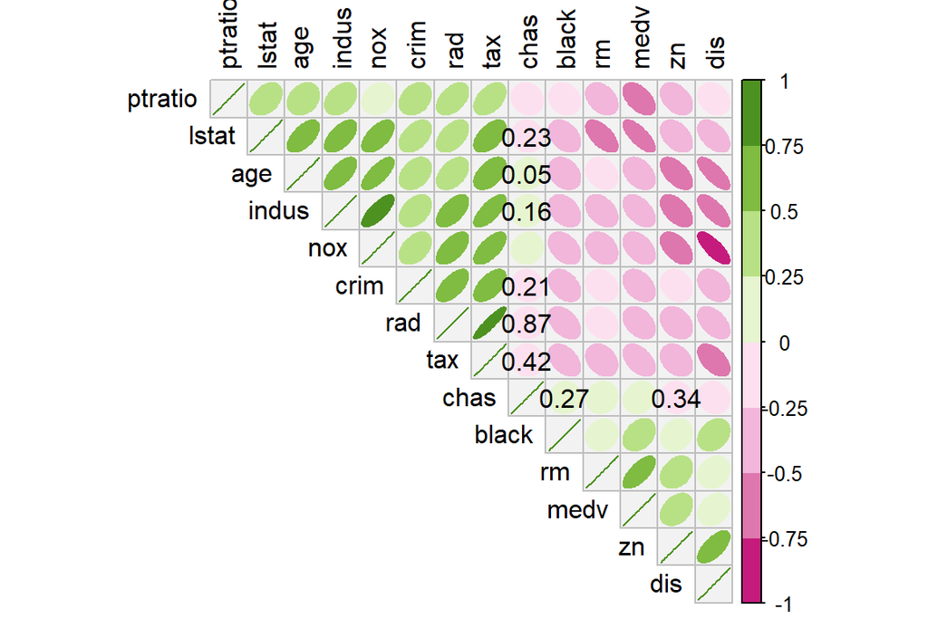

```r
colors <- brewer.pal(n = 9, name = "Pastel1")
signf_test <- cor.mtest(Boston, conf.level = .95)

corrplot(correlations, type = 'upper', method = 'ellipse', order = "hclust", col = brewer.pal(n = 8, name = "PiYG"), bg = colors[length(colors)],
         p.mat = signf_test$p, insig = 'p-value', sig.level = .05, tl.col = "black", tl.srt = 90)
```

Above `corrplot` shows negative correlations in pink and positive correlations in green. Narrowness of `method = 'ellipse'` indicates how high correlation is. For non-significant correlations (p>0.05), p-values are shown.

From the graph it can be observed that most of the variables correlate significantly with others. Only few pairs are not significantly correlated.

## Scale variables and categorical crimes

To be able to accurately classify the data, variable values need to be scaled so that all variables have a mean value of 0. It is done as follows (when all variables are numerical, as expected for classification analysis):

```r
scaled <- as.data.frame(scale(Boston))
class(scaled)
```

```
## [1] "data.frame"
```

```r
str(scaled)
```

```
## 'data.frame':    506 obs. of  14 variables:
##  $ crim   : num  -0.419 -0.417 -0.417 -0.416 -0.412 ...
##  $ zn     : num  0.285 -0.487 -0.487 -0.487 -0.487 ...
##  $ indus  : num  -1.287 -0.593 -0.593 -1.306 -1.306 ...
##  $ chas   : num  -0.272 -0.272 -0.272 -0.272 -0.272 ...
##  $ nox    : num  -0.144 -0.74 -0.74 -0.834 -0.834 ...
##  $ rm     : num  0.413 0.194 1.281 1.015 1.227 ...
##  $ age    : num  -0.12 0.367 -0.266 -0.809 -0.511 ...
##  $ dis    : num  0.14 0.557 0.557 1.077 1.077 ...
##  $ rad    : num  -0.982 -0.867 -0.867 -0.752 -0.752 ...
##  $ tax    : num  -0.666 -0.986 -0.986 -1.105 -1.105 ...
##  $ ptratio: num  -1.458 -0.303 -0.303 0.113 0.113 ...
##  $ black  : num  0.441 0.441 0.396 0.416 0.441 ...
##  $ lstat  : num  -1.074 -0.492 -1.208 -1.36 -1.025 ...
##  $ medv   : num  0.16 -0.101 1.323 1.182 1.486 ...
```

```r
summary(scaled)
```

```
##       crim                 zn               indus
##  Min.   :-0.419367   Min.   :-0.48724   Min.   :-1.5563
##  1st Qu.:-0.410563   1st Qu.:-0.48724   1st Qu.:-0.8668
##  Median :-0.390280   Median :-0.48724   Median :-0.2109
##  Mean   : 0.000000   Mean   : 0.00000   Mean   : 0.0000
##  3rd Qu.: 0.007389   3rd Qu.: 0.04872   3rd Qu.: 1.0150
##  Max.   : 9.924110   Max.   : 3.80047   Max.   : 2.4202
##       chas              nox                rm               age
##  Min.   :-0.2723   Min.   :-1.4644   Min.   :-3.8764   Min.   :-2.3331
##  1st Qu.:-0.2723   1st Qu.:-0.9121   1st Qu.:-0.5681   1st Qu.:-0.8366
##  Median :-0.2723   Median :-0.1441   Median :-0.1084   Median : 0.3171
##  Mean   : 0.0000   Mean   : 0.0000   Mean   : 0.0000   Mean   : 0.0000
##  3rd Qu.:-0.2723   3rd Qu.: 0.5981   3rd Qu.: 0.4823   3rd Qu.: 0.9059
##  Max.   : 3.6648   Max.   : 2.7296   Max.   : 3.5515   Max.   : 1.1164
##       dis               rad               tax             ptratio
##  Min.   :-1.2658   Min.   :-0.9819   Min.   :-1.3127   Min.   :-2.7047
##  1st Qu.:-0.8049   1st Qu.:-0.6373   1st Qu.:-0.7668   1st Qu.:-0.4876
##  Median :-0.2790   Median :-0.5225   Median :-0.4642   Median : 0.2746
##  Mean   : 0.0000   Mean   : 0.0000   Mean   : 0.0000   Mean   : 0.0000
##  3rd Qu.: 0.6617   3rd Qu.: 1.6596   3rd Qu.: 1.5294   3rd Qu.: 0.8058
##  Max.   : 3.9566   Max.   : 1.6596   Max.   : 1.7964   Max.   : 1.6372
##      black             lstat              medv
##  Min.   :-3.9033   Min.   :-1.5296   Min.   :-1.9063
##  1st Qu.: 0.2049   1st Qu.:-0.7986   1st Qu.:-0.5989
##  Median : 0.3808   Median :-0.1811   Median :-0.1449
##  Mean   : 0.0000   Mean   : 0.0000   Mean   : 0.0000
##  3rd Qu.: 0.4332   3rd Qu.: 0.6024   3rd Qu.: 0.2683
##  Max.   : 0.4406   Max.   : 3.5453   Max.   : 2.9865
```

Next, `crim` is cut to categorical variable according to quantiles to be able to later use it to train the model to predict the right crime rate class of an observation based on other variables.

```r
bins = quantile(scaled$crim)

crime <- cut(scaled$crim, breaks = bins, label = c('low', 'med_low', 'med_high', 'high'), include.lowest = TRUE)

#count table for each category level
table(crime)
```

```
## crime
##      low  med_low med_high     high
##      127      126      126      127
```

```r
#replace original crim with categorical crime variable

scaled <- dplyr::select(scaled, -crim)
scaled <- data.frame(scaled, crime)
head(scaled)
```

```
##           zn      indus       chas        nox        rm        age
## 1  0.2845483 -1.2866362 -0.2723291 -0.1440749 0.4132629 -0.1198948
## 2 -0.4872402 -0.5927944 -0.2723291 -0.7395304 0.1940824  0.3668034
## 3 -0.4872402 -0.5927944 -0.2723291 -0.7395304 1.2814456 -0.2655490
## 4 -0.4872402 -1.3055857 -0.2723291 -0.8344581 1.0152978 -0.8090878
## 5 -0.4872402 -1.3055857 -0.2723291 -0.8344581 1.2273620 -0.5106743
## 6 -0.4872402 -1.3055857 -0.2723291 -0.8344581 0.2068916 -0.3508100
##        dis        rad        tax    ptratio     black      lstat
## 1 0.140075 -0.9818712 -0.6659492 -1.4575580 0.4406159 -1.0744990
## 2 0.556609 -0.8670245 -0.9863534 -0.3027945 0.4406159 -0.4919525
## 3 0.556609 -0.8670245 -0.9863534 -0.3027945 0.3960351 -1.2075324
## 4 1.076671 -0.7521778 -1.1050216  0.1129203 0.4157514 -1.3601708
## 5 1.076671 -0.7521778 -1.1050216  0.1129203 0.4406159 -1.0254866
## 6 1.076671 -0.7521778 -1.1050216  0.1129203 0.4101651 -1.0422909
##         medv crime
## 1  0.1595278   low
## 2 -0.1014239   low
## 3  1.3229375   low
## 4  1.1815886   low
## 5  1.4860323   low
## 6  0.6705582   low
```

## Divide data for training and test sets

To be able to evaluate how well our model is predicting crime rate, I want to separate small fraction of the data (20%) for testing it, so it will not be used for training the model. Observations are selected randomly below for training or test sets.

```r
random_test_rows <- sample(nrow(scaled), size = nrow(scaled) * 0.2)

test_set <- scaled[random_test_rows, ]
train_set <- scaled[-random_test_rows, ]

#Check that resulting dfs are as should
dim(test_set)
```

```
## [1] 101  14
```

```r
dim(train_set)
```

```
## [1] 405  14
```

## Fitting linear discriminant analysis for crimes

Fitting classification model with `lda()` function using `crimes` as a categorical variable and all other (continuous) variables as predicting variables.

```r
lda_fit <- lda(crime ~ ., data = train_set)
lda_fit
```

```
## Call:
## lda(crime ~ ., data = train_set)
##
## Prior probabilities of groups:
##       low   med_low  med_high      high
## 0.2518519 0.2567901 0.2493827 0.2419753
##
## Group means:
##                  zn      indus        chas        nox         rm
## low       1.0174530 -0.9627662 -0.11793298 -0.8970748  0.4574674
## med_low  -0.1058810 -0.3257639 -0.04518867 -0.5842771 -0.1276132
## med_high -0.3751653  0.2266075  0.23442641  0.3485067  0.1960552
## high     -0.4872402  1.0171960 -0.07145661  1.0209468 -0.4022014
##                 age        dis        rad        tax    ptratio
## low      -0.8912839  0.8976551 -0.6868728 -0.7190590 -0.4848396
## med_low  -0.3758827  0.3847229 -0.5523004 -0.5172716 -0.0829453
## med_high  0.3917767 -0.3801493 -0.4110490 -0.2927905 -0.2511160
## high      0.8047085 -0.8548228  1.6373367  1.5134896  0.7798552
##                black       lstat        medv
## low       0.37955432 -0.77364295  0.52419927
## med_low   0.30799722 -0.12831880  0.02539276
## med_high  0.09569827 -0.03126444  0.24823414
## high     -0.82893268  0.89543911 -0.65528060
##
## Coefficients of linear discriminants:
##                 LD1          LD2         LD3
## zn       0.10137307  0.733923279 -1.02055414
## indus    0.12303987 -0.469763553  0.21767020
## chas    -0.09433274 -0.011060859  0.04100412
## nox      0.40394955 -0.795848064 -1.35524574
## rm      -0.12180402 -0.114906267 -0.17996727
## age      0.23932255 -0.240143798 -0.19334414
## dis     -0.02327701 -0.353097303  0.18334268
## rad      3.13219860  1.017473122  0.17554711
## tax     -0.01237795 -0.003721659  0.32129355
## ptratio  0.10447496 -0.008072193 -0.31619045
## black   -0.11968967  0.005074396  0.11620370
## lstat    0.21705986 -0.219847957  0.48177152
## medv     0.22666493 -0.473246223 -0.11074627
##
## Proportion of trace:
##    LD1    LD2    LD3
## 0.9403 0.0450 0.0146
```

### Visualization of model

Using `ggsci` color palette and `ggord` package to visualize `lda_fit`. To install `ggord` package from Github, I use `install_github` function from `devtools` package.

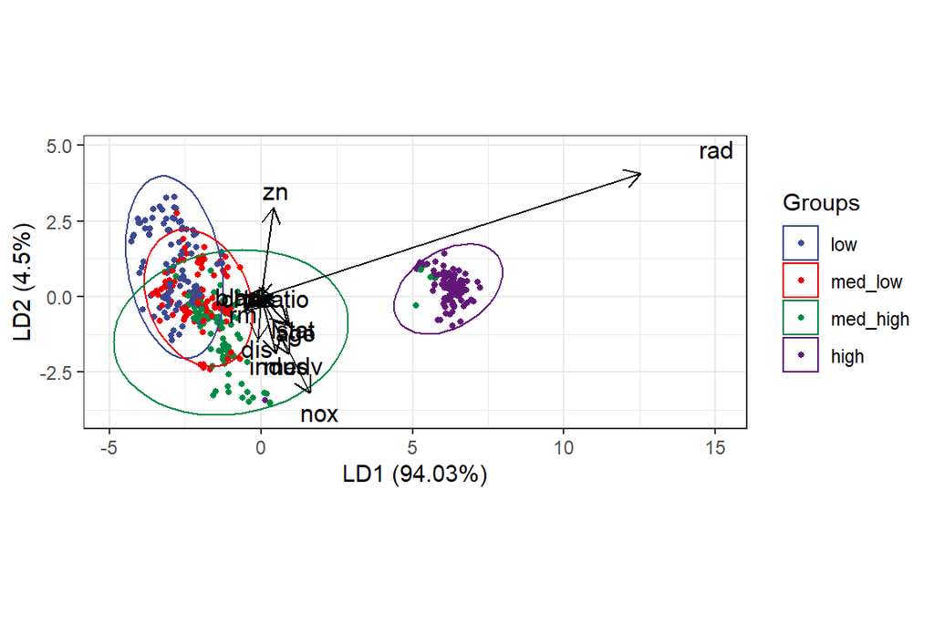

```r
#Convert crime factor levels to numeric to plot in different colors
crime_levels <- as.numeric(train_set$crime)

#I hate the default colors of the plot, so I'm using ggsci package palettes instead
#Good source for color palettes https://www.datanovia.com/en/blog/top-r-color-palettes-to-know-for-great-data-visualization/
library(ggsci)
library(devtools)
install_github("fawda123/ggord")
library(ggord)

cols <- pal_aaas()(4)

#color vector corresponding to levels of crimes in lda
cols_crimes <- cols[crime_levels]

#Plot with nicer colors

ggord(lda_fit, train_set$crime, poly = FALSE, arrow=.3, veclsz = .5, vec_ext = 4, size=1, cols = cols)
```

There are so many variables in the model, that the arrows look a bit messy. However, it is easy to see still which variables affect the classification most (zn, rad, nox). This `ggord` package was very nice and easy to use. You can see that the model does not classify crime rates perfectly but I would say it does pretty good job distinguishing `high` crime rate from others in `train_set`.